# Exploring the BRFSS data

## Setup

### Load packages

```r
library(ggplot2)
library(dplyr)
```

### Load data

```r
load("brfss2013.RData")
```

## Part 1: Data

The Behavioral Risk Factor Surveillance System (BRFSS) is a collaborative project between all of the states in the United States (US) and participating US territories and the Centers for Disease Control and Prevention (CDC). The BRFSS is administered and supported by CDC’s Population Health Surveillance Branch, under the Division of Population Health at the National Center for Chronic Disease Prevention and Health Promotion. BRFSS is an ongoing surveillance system designed to measure behavioral risk factors for the non-institutionalized adult population (18 years of age and older) residing in the US. The BRFSS was initiated in 1984, with 15 states collecting surveillance data on risk behaviors through monthly telephone interviews. Over time, the number of states participating in the survey increased; by 2001, 50 states, the District of Columbia, Puerto Rico, Guam, and the US Virgin Islands were participating in the BRFSS. Today, all 50 states, the District of Columbia, Puerto Rico, and Guam collect data annually and American Samoa, Federated States of Micronesia, and Palau collect survey data over a limited point- in-time (usually one to three months). In this document, the term “state” is used to refer to all areas participating in BRFSS, including the District of Columbia, Guam, and the Commonwealth of Puerto Rico.

The BRFSS objective is to collect uniform, state-specific data on preventive health practices and risk behaviors that are linked to chronic diseases, injuries, and preventable infectious diseases that affect the adult population. Factors assessed by the BRFSS in 2013 include tobacco use, HIV/AIDS knowledge and prevention, exercise, immunization, health status, healthy days — health-related quality of life, health care access, inadequate sleep, hypertension awareness, cholesterol awareness, chronic health conditions, alcohol consumption, fruits and vegetables consumption, arthritis burden, and seatbelt use. Since 2011, BRFSS conducts both landline telephone- and cellular telephone-based surveys. In conducting the BRFSS landline telephone survey, interviewers collect data from a randomly selected adult in a household. In conducting the cellular telephone version of the BRFSS questionnaire, interviewers collect data from an adult who participates by using a cellular telephone and resides in a private residence or college housing.

Health characteristics estimated from the BRFSS pertain to the non-institutionalized adult population, aged 18 years or older, who reside in the US. In 2013, additional question sets were included as optional modules to provide a measure for several childhood health and wellness indicators, including asthma prevalence for people aged 17 years or younger.

## Part 2: Research questions

**Research quesion 1:** Is there any correlation between the number of hours a respondent sleeps on average and the reported number of days where a respondent felt full of energy in the past 30 Days?

**Research quesion 2:** Is there any correlation between a level of education obtained and overall life satisfaction?

**Research quesion 3:** Is there any correlation between reported level of income earned and general health?

## Part 3: Exploratory data analysis

**Research quesion 1:** Is there any correlation between the number of hours a respondent sleeps on average and the reported number of days where a respondent felt full of energy in the past 30 Days?

```r
Q1 <- brfss2013 %>%
  select(qlhlth2 , sex , sleptim1) %>%
  filter(!is.na(qlhlth2), !is.na(sex), sleptim1 <= 12 )

Q1 %>%
  group_by(qlhlth2) %>%
  summarise(count = n())
```

```
## # A tibble: 23 x 2
##    qlhlth2 count
##  *   <int> <int>
##  1       0    90
##  2       1     6
##  3       2    19
##  4       3    11
##  5       4     6
##  6       5    25
##  7       6     1
##  8       7     6
##  9       8     5
## 10      10    16
## # … with 13 more rows
```

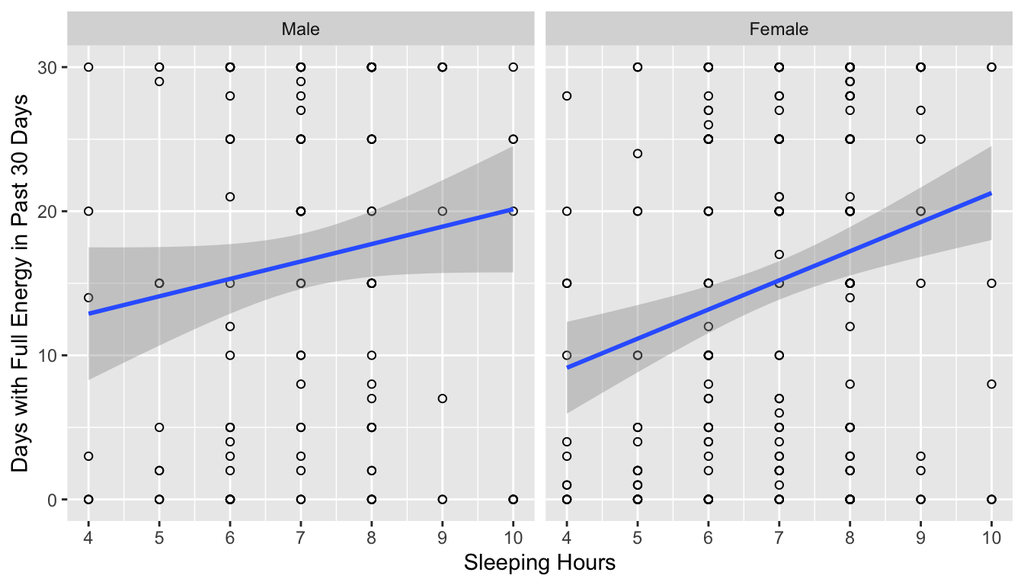

```r
Q1 %>%
  ggplot(aes(x = sleptim1, y = qlhlth2)) +
  geom_point(shape = 1) +
  geom_smooth(method = lm) +
  scale_x_continuous(limits = c(4,10), breaks = 4:10) +
  facet_grid(. ~ sex) +
  xlab("Sleeping Hours") +
  ylab("Days with Full Energy in Past 30 Days")
```

A positive linear relationship between the time of sleeping and the days with full energy. The more he or she sleeps, the more energy he or she will have for a day.

**Research quesion 2:** Is there any correlation between a level of education obtained and overall life satisfaction?

```r
Q2 <- brfss2013 %>%
  select(lsatisfy, sex, educa)
Q2 <- na.omit(Q2)

Q2 %>%
  group_by(lsatisfy) %>%
  summarise(count = n())
```

```
## # A tibble: 4 x 2
##   lsatisfy          count
## * <fct>             <int>
## 1 Very satisfied     5378
## 2 Satisfied          5506
## 3 Dissatisfied        598
## 4 Very dissatisfied   161
```

```r
Q2 %>%
  group_by(sex) %>%
  summarise(count = n())
```

```
## # A tibble: 2 x 2
##   sex    count
## * <fct>  <int>
## 1 Male    4078
## 2 Female  7565
```

```r
Q2 %>%
  group_by(educa) %>%
  summarise(count = n())
```

```
## # A tibble: 6 x 2
##   educa                                                        count
## * <fct>                                                        <int>
## 1 Never attended school or only kindergarten                      10
## 2 Grades 1 through 8 (Elementary)                                496
## 3 Grades 9 though 11 (Some high school)                         1078
## 4 Grade 12 or GED (High school graduate)                        3708
## 5 College 1 year to 3 years (Some college or technical school)  3055
## 6 College 4 years or more (College graduate)                    3296
```

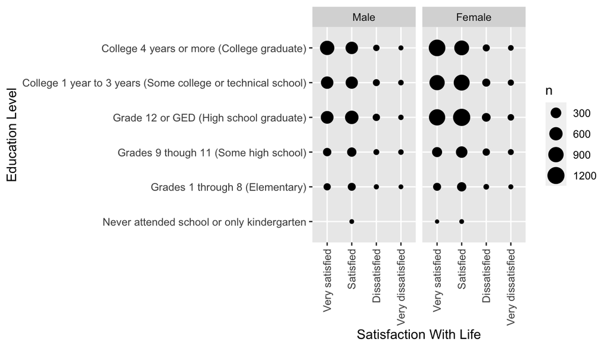

```r
Q2 %>%
  ggplot(aes(x = lsatisfy, y=educa))+
  geom_count() +
  theme(axis.text.x = element_text(angle = 90, vjust = 0.5, hjust=1))+
  facet_grid(. ~  sex) +
  xlab("Satisfaction With Life") +
  ylab ("Education Level")
```

**Research quesion 3:** Is there any correlation between reported level of income earned and general health?

```r
Q3 <- brfss2013 %>%
  select(genhlth, income2)
Q3 <- na.omit(Q3)

Q3 %>%
  group_by(genhlth) %>%
  summarise(count = n())
```

```
## # A tibble: 5 x 2
##   genhlth    count
## * <fct>      <int>
## 1 Excellent  74254
## 2 Very good 138247
## 3 Good      127701
## 4 Fair       55602
## 5 Poor       23116
```

```r
Q3 %>%
  group_by(income2) %>%
  summarise(count = n())
```

```
## # A tibble: 8 x 2
##   income2            count
## * <fct>              <int>
## 1 Less than $10,000  25252
## 2 Less than $15,000  26633
## 3 Less than $20,000  34705
## 4 Less than $25,000  41563
## 5 Less than $35,000  48687
## 6 Less than $50,000  61319
## 7 Less than $75,000  65102
## 8 $75,000 or more   115659
```

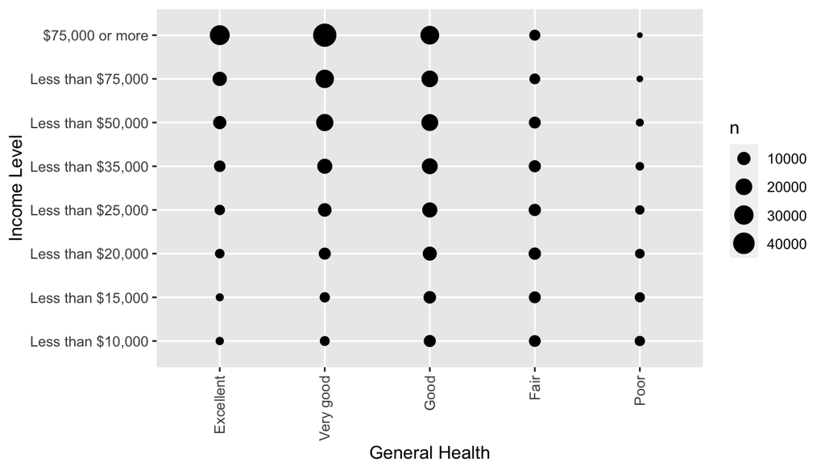

```r
Q3 %>%
  ggplot(aes(x = genhlth, y=income2))+
  geom_count() +
  theme(axis.text.x = element_text(angle = 90, vjust = 0.5, hjust=1))+
  xlab("General Health") +
  ylab ("Income Level")
```

Income Level and General Health are correlated positively.